# Enhancer - target gene properties (Figure 3d,e)

Schraivogel, Gschwind et al.

January 17, 2020

This vignette reproduces the analysis in Figure 3d,e of Schraivogel, Gschwind, et al.

## Data

This analysis is based on the ehancer screen experiments. Candidate enhancers within 2 genomic regions on chromosome 8 and 11 were each targeted with 4 gRNA. TAP-seq was used to measure the expression levels of all genes within these regions.

Differential gene expression analyses (MAST) was used to identify target genes of perturbed enhancers: Genes differentially expressed between cells with a given enhancer perturbation versus 1000 randomly selected cells without that perturbation were considered target genes for that enhancer. All performed tests were corrected for multiple testing by calculating the false positive rate (FDR) and only enhancer - target pairs (ETPs) with an FDR below 0.05 were retained.

The code for differential gene expression analyses can be found in *“scripts/analyses/differential_expression.R”* and *“scripts/analyses/process_de_results.R”*. Different models were explored and more analyses can be found in *“vignettes/Figure2.Rmd”*.

All enhancer screen analyses can be performed by running:

```bash
snakemake --use-conda enhancer_screen
```

The following data is required to reproduce the analysis in this vignette:

```r
suppressPackageStartupMessages(library(knitr))
suppressPackageStartupMessages(library(tidyverse))

# download differential gene expression output. if the snakemake workflow was executed, this file
# can be found under 'data/diff_expr_screen_nGenesCovar.csv'
de_output <- read.csv(url("http://steinmetzlab.embl.de/TAPdata/diff_expr_screen_nGenesCovar.csv"),
                      stringsAsFactors = FALSE)

# change sample id to a more meaningful name and add a variable for significant ETPs
de_output <- de_output %>%
  mutate(sample = paste0("Chr", sub("iScreen1", "", sample))) %>%
  mutate(significant = if_else(pval_adj_allTests < 0.05, true = "sig", false = "non_sig"))
```

## Number of cis-enhancers per gene (Figure 3d)

Cis enhancer gene pairs are extracted by selecting pairs within the same regions and at least 1kb away from the target genes TSS. Furthermore, any significant hits that lead to an increase in expression of their target genes are filtered out, as they probably act through alternative mechanisms. The number of cis-enhancers per gene are counted and plotted.

```r
# extract cis enhancer - gene pairs and remove significant pairs that increase gene expression
cis_enh_perts <- de_output %>%
  filter(enh_type == "cis", abs(dist_to_tss) >= 1000) %>%
  filter(!(significant == "sig" & manual_lfc > 0))

# only retain hits within the same target region (discard out of region control enhancers)
cis_enh_perts <- cis_enh_perts %>%
  filter(enh_chr == sub("Chr", "", sample))

# count the number of enhancers for each gene
enh_per_gene <- cis_enh_perts %>%
  group_by(sample, gene) %>%
  summarize(enh = sum(significant == "sig"))

# compute proportion of genes with at least one discovered enhancer
prop_with_enh <- enh_per_gene %>%
  summarize(enh = sum(enh > 0),
            genes = n(),
            prop_genes_with_enh = round(enh / genes, digits = 2))

# print table
kable(prop_with_enh)
```

| sample | enh | genes | prop_genes_with_enh |
| --- | --- | --- | --- |
| Chr11 | 25 | 79 | 0.32 |
| Chr8 | 16 | 68 | 0.24 |

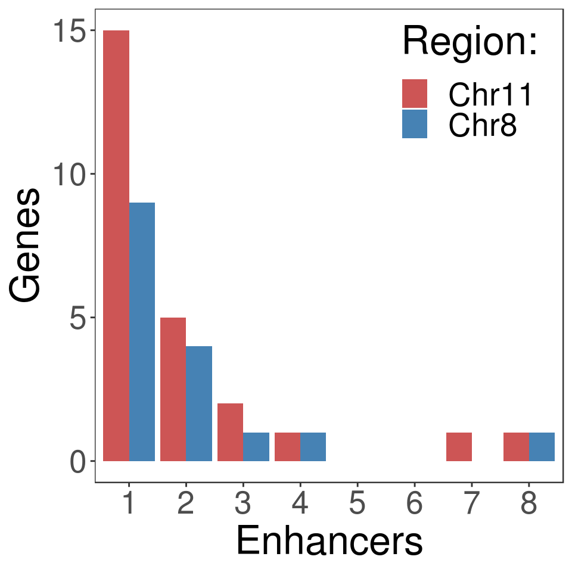

```r
# compute number of genes per enhancer count
enh_counts <- enh_per_gene %>%
  filter(enh > 0) %>%
  group_by(sample, enh) %>%
  summarize(genes = n()) %>%
  spread(key = "sample", value = "genes", fill = 0) %>%
  gather(key = "sample", value = "genes", -enh)

# plot number of genes per enhancer count
ggplot(enh_counts, aes(x = factor(enh, levels = seq_len(max(enh))), y = genes, fill = sample)) +
  geom_bar(stat = "identity", position = "dodge") +
  labs(x = "Enhancers", y = "Genes",
       fill = "Region:") +
  scale_fill_manual(values = c("Chr11" = "indianred3", "Chr8" = "steelblue")) +
  scale_x_discrete(drop = FALSE) +
  theme_bw() +
  theme(text = element_text(size = 25), panel.grid = element_blank(),
        legend.position = c(0.8, 0.85))
```

## P-value vs distance to TSS (Figure 3e)

The negative log10 p-value is plotted as function of distance to TSS to show that strong associations (high -log10 p-value) are located close to their target genes TSS. The proportion of individual gRNAs confirming an ETP are used to assign a confidence level to each ETP.

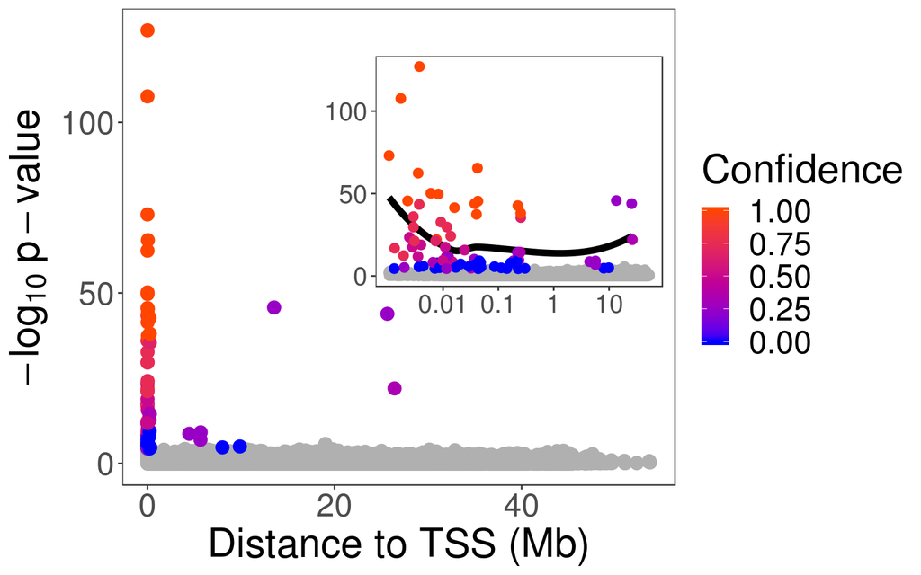

```r
# calculate -log10 p-value
cis_enh_perts <- mutate(cis_enh_perts, neg_log10_pvalue = -log10(pvalue))

# set gRNA hits to NA for non-significant hits
cis_enh_perts_plot <- cis_enh_perts %>%
  mutate(grna_hits = if_else(significant != "sig", true = as.integer(NA), false = grna_hits),
         prop_grna_hits = if_else(significant != "sig", true = as.numeric(NA),
                                  false = prop_grna_hits))

# plot decay of association strength over distance within 1Mb of TSS
p1 <- ggplot(cis_enh_perts_plot, aes(x = abs(dist_to_tss) / 1e6, y = neg_log10_pvalue,
                                     color = prop_grna_hits)) +
    labs(x = "Distance to TSS (Mb)", y = expression(-log[10] ~ p - value),
         color = "Confidence") +
    geom_point(data = filter(cis_enh_perts_plot, significant == "non_sig"), size = 3.5) +
    geom_point(data = filter(cis_enh_perts_plot, significant == "sig"), size = 3.5) +
    scale_color_gradient(low = "blue", high = "orangered", na.value = "gray69") +
    theme_bw() +
    theme(text = element_text(size = 25), panel.grid = element_blank())

# same plot, but with logarithmic distance
p2 <- ggplot(cis_enh_perts_plot, aes(x = abs(dist_to_tss) / 1e6, y = neg_log10_pvalue,
                                     color = prop_grna_hits)) +
    geom_smooth(data = filter(cis_enh_perts_plot, significant == "sig"),
                method = "loess", se = FALSE, color = "black", lwd = 2) +
    labs(x = "Distance to TSS (Mb)", y = expression(-log[10] ~ p - value)) +
    geom_point(data = filter(cis_enh_perts_plot, significant == "non_sig"), size = 2.5) +
    geom_point(data = filter(cis_enh_perts_plot, significant == "sig"), size = 2.5) +
    scale_x_log10(breaks = c(0.01, 0.1, 1, 10), labels = c("0.01", "0.1", "1", "10")) +
    scale_color_gradient(low = "blue", high = "orangered", na.value = "gray69") +
    theme_bw() +
    theme(text = element_text(size = 20), axis.title = element_blank(), legend.position = "none",
          panel.grid = element_blank(), plot.background = element_rect(fill = NA))

# add logarithmic plot as inset of linear plot
p1 +
  annotation_custom(
    grob = ggplotGrob(p2),
    xmin = 18,
    xmax = 56,
    ymin = 40,
    ymax = 122
  )
```

More enhancer analyses can be found in *“scripts/analyses/map_enhancers.Rmd”*.